# Negativas de acesso a informação no governo Federal

Uso da LGPD em pedidos de acesso a informação

```r
set.seed(1014)

knitr::knit_hooks$set(inline = function(x) prettyNum(x, big.mark = ".", decimal.mark = ","))

options(
  digits = 1,
  scipen = 999,
  OutDec = ",",
  knitr.kable.NA = "",
  radian.auto_match = FALSE
)

Sys.setenv(LANGUAGE = "pt-br")
Sys.setlocale("LC_TIME", "pt_BR")
```

```
#> [1] ""
```

```r
library(tidyverse)
library(lubridate)
library(here)
`%notin%` <- function(x, y) !(x %in% y)
```

```r
source(here("src/0-paleta-de-cores.R"), encoding = "UTF-8")

theme_set(theme_minimal())

theme_update(
  panel.grid.minor = element_blank(),
  panel.background = element_rect(fill = "gray97", color = "transparent")
)
```

```r
pedidos_cgu <- "dados/load/rds/pedidos-cgu.rds" %>%
  here() %>%
  readRDS() %>%
  rename(orgao = orgaodestinatario) %>%
  filter(decisao %notin% c(
    "Pergunta Duplicada/Repetida",
    "Não se trata de solicitação de informação"
  ))

recursos_cgu <- "dados/load/rds/recursos-cgu.rds" %>%
  here() %>%
  readRDS() %>%
  rename(orgao = orgaodestinatario) %>%
  distinct() %>%
  group_by(id_pedido) %>%
  filter(row_number() == 1) %>%
  ungroup()

pedidos_clean <- "dados/load/rds/pedidos-clean.rds" %>%
  here() %>%
  readRDS()

recursos_clean <- "dados/load/rds/recursos-clean.rds" %>%
  here() %>%
  readRDS() %>%
  distinct() %>%
  group_by(id_pedido) %>%
  filter(row_number() == 1) %>%
  ungroup()
```

```r
pedidos_clean <- pedidos_clean %>%
  left_join(select(pedidos_cgu, id_pedido, data_registro)) %>%
  mutate(
    usa_lgpd_pedido_resumido = if_else(
      year(data_registro) > 2017,
      str_detect(resumo_solicitacao_clean, "LGPD"),
      FALSE
    ),
    usa_lgpd_pedido = if_else(
      year(data_registro) > 2017,
      str_detect(detalhamento_solicitacao_clean, "LGPD"),
      FALSE
    ),
    usa_lgpd_resposta = if_else(
      year(data_registro) > 2017,
      str_detect(resposta_clean, "LGPD"),
      FALSE
    )
  ) %>% select(-data_registro)

recursos_clean <- recursos_clean %>%
  left_join(select(recursos_cgu, id_pedido, id_recurso, data_registro)) %>%
  mutate(
    usa_lgpd_recurso = if_else(
      year(data_registro) > 2017,
      str_detect(desc_recurso_clean, "LGPD"),
      FALSE
    ),
    usa_lgpd_resposta_recurso = if_else(
      year(data_registro) > 2017,
      str_detect(resposta_recurso_clean, "LGPD"),
      FALSE
    ),
    usa_lgpd = usa_lgpd_recurso | usa_lgpd_resposta_recurso
  ) %>% select(-data_registro)

lgpd <- pedidos_cgu %>%
  select(
    id_pedido, orgao, data_registro,
    resumo_solicitacao, detalhamento_solicitacao,
    resposta, decisao, assunto_pedido
  ) %>%
  left_join(pedidos_clean) %>%
  mutate(
    usa_lgpd_assunto = assunto_pedido == "Dados Pessoais - LGPD",
    usa_lgpd_pedido_resumido = replace_na(usa_lgpd_pedido_resumido, FALSE),
    usa_lgpd = !(
      !usa_lgpd_pedido_resumido &
      !usa_lgpd_pedido &
      !usa_lgpd_resposta &
      !usa_lgpd_assunto
  ))
```

#### Detectando termos relacionados a LGPD

Foi realizada uma busca no pedido, no resumo do pedido, na resposta, nos recursos e nas respostas dos recursos. A busca foi feita com a regex:

- `"lei geral de protecao de dados|lei de protecao de dados pessoais|lgpd|13709|13 709"`

Também foi detectado na base de dados a nomenclatura **Dados pessoais - LGPD** no campo de assunto do pedido.

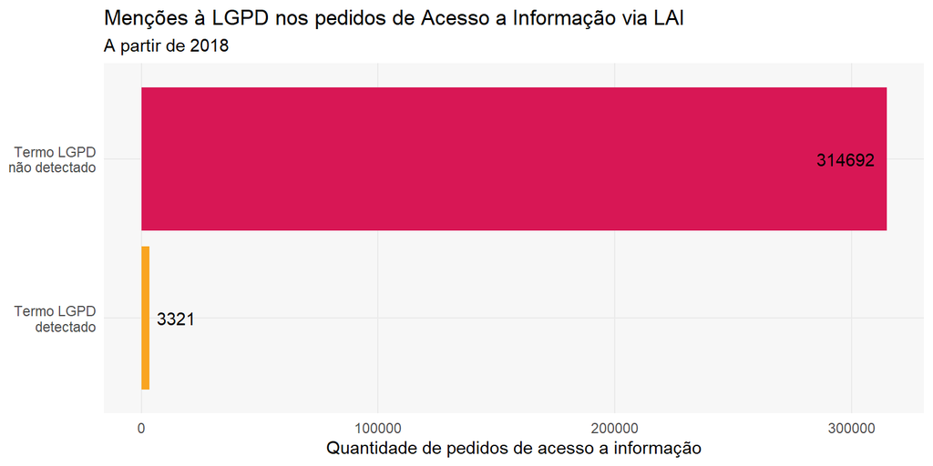

```r
lgpd %>%
  filter(data_registro >= ymd("2018-01-01")) %>%
  count(usa_lgpd) %>%
  mutate(
    usa_lgpd = if_else(
      usa_lgpd,
      "Termo LGPD\ndetectado",
      "Termo LGPD\nnão detectado"
  )) %>%
  ggplot(aes(x = usa_lgpd, y = n, fill = usa_lgpd)) +
  geom_col(show.legend = F) +
  geom_text(
    aes(
      label = if_else(
        usa_lgpd == "Termo LGPD\ndetectado",
        n,
        NA_integer_)
    ),
    hjust = -0.2
  ) +
  geom_text(
    aes(
      label = if_else(
        usa_lgpd != "Termo LGPD\ndetectado",
        n,
        NA_integer_)
    ),
    hjust = 1.2
  ) +
  scale_fill_manual(
    values = c(cores_aep[["laranja"]], cores_aep[["rosa"]])
  ) +
  coord_flip() +
  labs(
    title = "Menções à LGPD nos pedidos de Acesso a Informação via LAI",
    subtitle = "A partir de 2018",
    x = NULL,
    y = "Quantidade de pedidos de acesso a informação"
  )
```

```r
lgpd_counts <- lgpd %>%
  select(data_registro, where(is.logical)) %>%
  filter(usa_lgpd) %>%
  mutate(
    data_registro,
    mencao_lgpd = case_when(
      !usa_lgpd_assunto &
        !usa_lgpd_pedido &
        !usa_lgpd_pedido_resumido ~ str_glue(
          "Solicitante não menciona LGPD em pedido,",
          " órgão menciona na resposta"
        ),
      TRUE ~ "Solicitante menciona LGPD no pedido ou assunto do pedido"
    )
  ) %>%
  count(data_registro, mencao_lgpd)
```

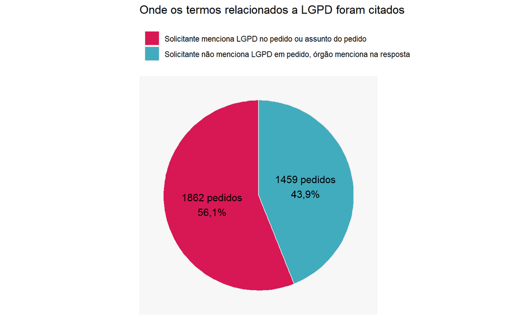

```r
my_lbl <- function(x) scales::percent(x, accuracy = 0.1, decimal.mark = ",")

lgpd_counts %>%
  count(mencao_lgpd, wt = n) %>%
  mutate(
    prop = n / sum(n),
    ypos = cumsum(prop) - 0.5 * prop
  ) %>%
  mutate(mencao_lgpd = str_replace(mencao_lgpd, "\\\n", " ")) %>%
  ggplot(aes(x = "", y = prop, fill = mencao_lgpd)) +
  geom_col(width = 1, color = cores_tb[["cinza_quase_branco"]]) +
  coord_polar("y", start = 0) +
  geom_text(
    aes(y = 1-ypos, label = str_glue("{n} pedidos\n{my_lbl(prop)}")),
    size = 4
  ) +
  labs(
    title = "Onde os termos relacionados a LGPD foram citados",
    fill = NULL,
    x = NULL,
    y = NULL
  ) +
  scale_fill_manual(values = c(cores_aep[["rosa"]], cores_tb[["azul"]])) +
  theme(
    legend.position = "top",
    legend.justification = "left",
    legend.direction = "vertical",
    axis.text = element_blank(),
    panel.grid = element_blank()
  )
```

### Evolução de uso da LGPD em pedidos LAI

#### Primeiras menções a LGPD

```r
d <- lgpd %>%
  filter(usa_lgpd) %>%
  arrange(data_registro) %>%
  filter(row_number() < 11) %>%
  pull(id_pedido)

esic_url <- "http://www.consultaesic.cgu.gov.br/busca/_layouts/15/DetalhePedido/DetalhePedido.aspx?nup="

pedidos_cgu %>%
  filter(id_pedido %in% d) %>%
  transmute(
    Protocolo = str_glue(
      '<a href="{esic_url}{protocolo_pedido}">{protocolo_pedido}</a>'
    ),
    Órgão = orgao,
   `Data registro` = dmy(ts_registro),
    Assunto = assunto_pedido,
    Decisão = decisao,
   `Resumo pedido` = resumo_solicitacao
  ) %>%
  DT::datatable(
    caption = str_glue(
      'Primeiras menções a LGPD',
      ' (clique no nº de protocolo para acessar o pedido no E-sic)'
    ),
    options = list(pageLength = 9, dom = 'tip'),
    filter = 'top',
    escape = FALSE
  )
```

|  | Protocolo | Órgão | Data registro | Assunto | Decisão | Resumo pedido |
| --- | --- | --- | --- | --- | --- | --- |
| 1 | 00077001198201892 | SGPR – Secretaria-Geral da Presidência da República | 2018-08-30 | Legislação | Acesso Concedido | pedidos de veto - Lei 13.709/18 |
| 2 | 00077001253201844 | SEGOV/PR - Secretaria de Governo da Presidência da República | 2018-09-10 | Legislação | Acesso Concedido | Solicito documentos relativos a sanção/veto do PLC 53/18 (Lei 13.709/18) |
| 3 | 03950003349201890 | ME - Ministério da Economia | 2018-09-11 | Serviços Públicos | Acesso Concedido | Solicito documentos relativos a sanção/veto do PLC 53/18 (Lei 13.709/18) |
| 4 | 01390001722201835 | MCTI – Ministério da Ciência, Tecnologia, Inovações | 2018-09-11 | Telecomunicações | Acesso Concedido | Solicito documentos relativos a sanção/veto do PLC 53/18 (Lei 13.709/18) |
| 5 | 52750000722201812 | ME - Ministério da Economia | 2018-09-11 | Outros em Comércio e serviços | Acesso Concedido | Solicito documentos relativos a sanção/veto do PLC 53/18 (Lei 13.709/18) |
| 6 | 25820005743201881 | MS – Ministério da Saúde | 2018-09-11 | Outros em Saúde | Acesso Parcialmente Concedido | Solicito documentos relativos a sanção/veto do PLC 53/18 (Lei 13.709/18) |
| 7 | 21900001314201893 | MAPA – Ministério da Agricultura, Pecuária e Abastecimento | 2018-09-11 | Produção Agropecuária | Acesso Concedido | Solicito documentos relativos a sanção/veto do PLC 53/18 (Lei 13.709/18) |
| 8 | 00075001324201829 | CGU – Controladoria-Geral da União | 2018-09-11 | Serviços Públicos | Acesso Parcialmente Concedido | Solicito documentos relativos a sanção/veto do PLC 53/18 (Lei 13.709/18) |
| 9 | 01390001725201879 | MCTI – Ministério da Ciência, Tecnologia, Inovações | 2018-09-11 | Telecomunicações | Acesso Concedido | Informações referentes à Mensagem de Veto nº 451, de 14 de agosto de 2018 |
| 10 | 00077001271201826 | CC-PR – Casa Civil da Presidência da República | 2018-09-14 | Legislação | Acesso Concedido | Exposição de motivos de lei |

#### Histórico geral

O gráfico abaixo mostra a evolução dos pedidos onde alguma menção à LGPD foi detectada tanto no pedido quanto na resposta.

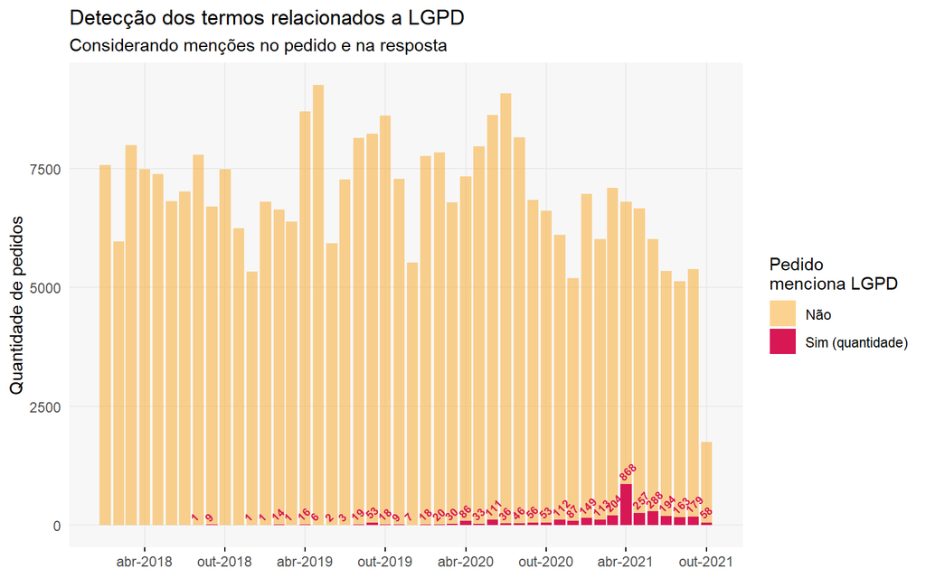

```r
lgpd %>%
  filter(data_registro >= ymd("2018-01-01")) %>%
  count(data_registro, usa_lgpd) %>%
  mutate(usa_lgpd = if_else(usa_lgpd, "Sim (quantidade)", "Não")) %>%
  ggplot(aes(x = data_registro, y = n, fill = reorder(usa_lgpd, -n))) +
  geom_col() +
  geom_text(
    data = . %>%
      add_count(data_registro, wt = n) %>%
      filter(usa_lgpd == "Não") %>%
      mutate(nn - n) %>%
      filter(`nn - n` > 0),
    aes(
      y = `nn - n`,
      label = `nn - n`,
    ),
    color = cores_aep[["rosa"]],
    vjust = -.5,
    hjust = 0,
    size = 2.5,
    fontface = "bold",
    angle = 45
  ) +
  labs(
    title = "Detecção dos termos relacionados a LGPD",
    subtitle = "Considerando menções no pedido e na resposta",
    x = NULL,
    y = "Quantidade de pedidos",
    fill = "Pedido\nmenciona LGPD"
  ) +
  scale_fill_manual(values = c(alpha(cores_aep[["laranja"]], .5),
                               cores_aep[["rosa"]])) +
  scale_x_date(date_breaks = "6 months", date_labels = "%b-%Y") +
  theme(axis.ticks.x = element_line())
```

#### Solicitantes e órgãos mencionam LGPD

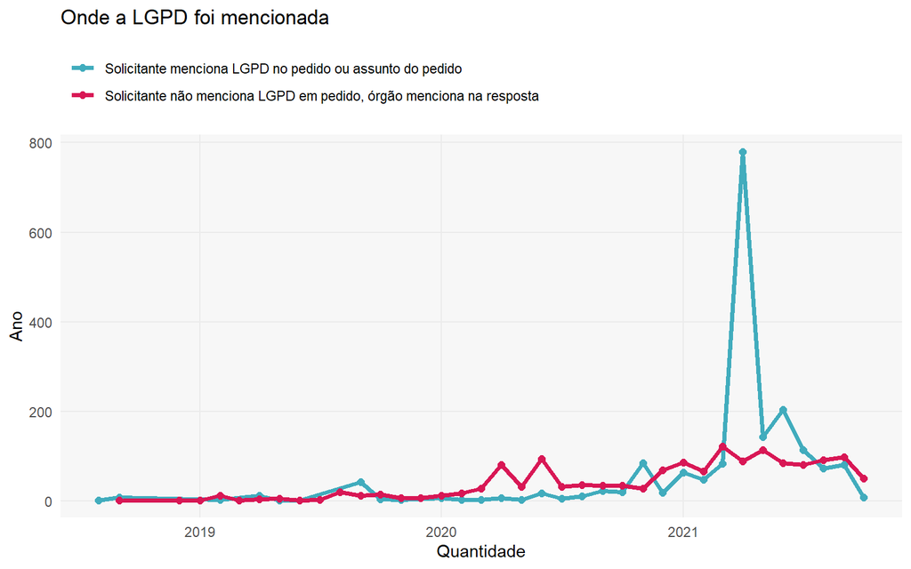

```r
lgpd_counts %>%
  ggplot(aes(x = data_registro, y = n, color = reorder(mencao_lgpd, -n))) +
  geom_line(size = 1.3) +
  geom_point(size = 2) +
  scale_color_manual(values = c(cores_tb[["azul"]], cores_aep[["rosa"]])) +
  labs(
    title = "Onde a LGPD foi mencionada",
    color = NULL,
    x = "Quantidade",
    y = "Ano"
  ) +
  theme(
    legend.position = "top",
    legend.direction = "vertical",
    legend.justification = "left"
  )
```

#### Solicitantes e órgãos mencionam LGPD - ano a ano

Analisando ano a ano, agregando os meses, as solicitações respondidas com menções à LGPD, praticamente dobrou em 2021 em relação à 2020.

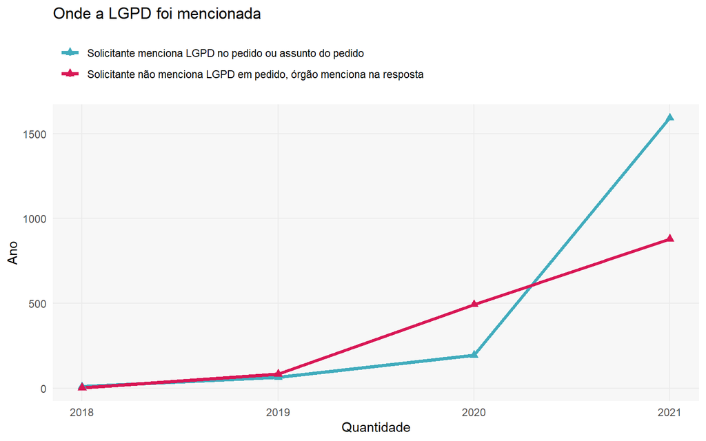

```r
lgpd_counts %>%
  count(ano = year(data_registro), mencao_lgpd,
        wt = n, name = "n") %>%
  ggplot(aes(x = ano, y = n, color = mencao_lgpd)) +
  geom_line(
    data = . %>%
      filter(mencao_lgpd != str_glue("Solicitante não menciona LGPD em pedido,",
                                     "\nórgão menciona na resposta")),
    size = 1.3) +
  geom_point(
    data = . %>%
      filter(mencao_lgpd != str_glue("Solicitante não menciona LGPD em pedido,",
                                     "\nórgão menciona na resposta")),
    size = 2.3, shape = 17) +
  geom_line(
    data = . %>%
      filter(mencao_lgpd == str_glue("Solicitante não menciona LGPD em pedido,",
                                     "\nórgão menciona na resposta")),
    size = 1.3) +
  geom_point(
    data = . %>%
      filter(mencao_lgpd == str_glue("Solicitante não menciona LGPD em pedido,",
                                     "\nórgão menciona na resposta")),
    size = 2) +
  scale_color_manual(values = c(cores_tb[["azul"]], cores_aep[["rosa"]])) +
  labs(title = "Onde a LGPD foi mencionada",
       color = NULL,
       x = "Quantidade",
       y = "Ano"
       ) +
  theme(
    legend.position = "top",
    legend.direction = "vertical",
    legend.justification = "left"
  )
```

#### Órgãos que mencionaram LGPD na resposta

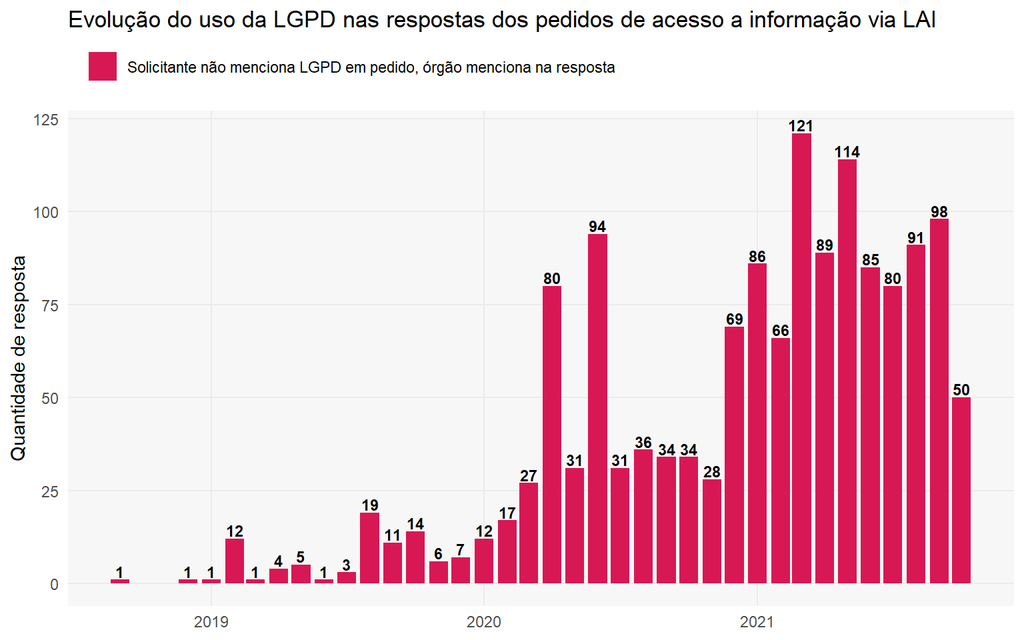

```r
lgpd_counts %>%
  filter(str_detect(mencao_lgpd, "Solicitante não menciona LGPD em pedido")) %>%
  mutate(mencao_lgpd = str_replace(mencao_lgpd, "\\n", " ")) %>%
  ggplot(aes(x = data_registro, y = n, fill = mencao_lgpd)) +
  geom_col() +
  geom_text(aes(label = n), size = 3, vjust = -0.2, fontface = "bold", check_overlap = T) +
  scale_fill_manual(values = cores_aep[["rosa"]]) +
  labs(
    y = "Quantidade de resposta",
    x = NULL,
    title = str_glue(
      "Evolução do uso da LGPD nas respostas dos ",
      "pedidos de acesso a informação via LAI"
    ),
    fill = NULL
  ) +
  theme(
    legend.justification = "left",
    legend.position = "top"
  )
```

### Uso da LGPD pelos órgãos para responder uma demanda qualquer via LAI

Quantidade de vezes que órgãos citaram LGPD para responder algum pedido:

**O termo LGPD foi detectado na resposta do pedido, mas o solicitante não menciona o assunto no pedido (o termo não é detectado no pedido).**

#### Valores acumulados

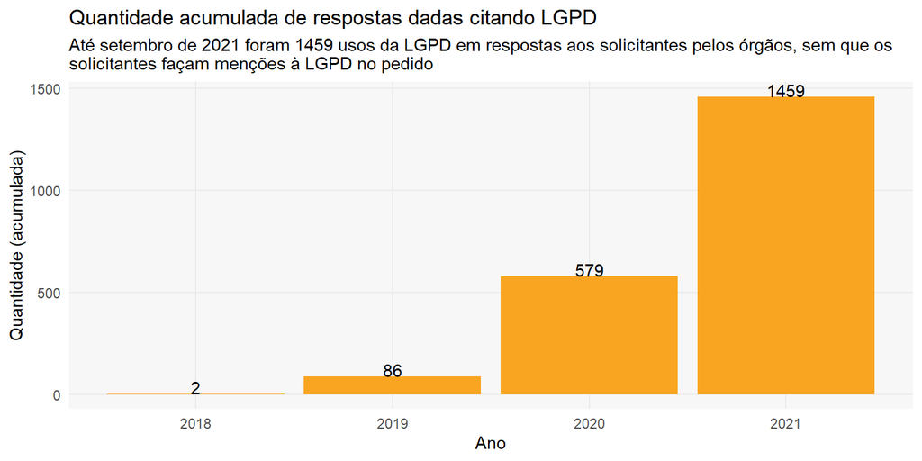

```r
qt_lgpd <- lgpd %>%
  filter(
    usa_lgpd_resposta &
     !usa_lgpd_pedido &
     !usa_lgpd_pedido_resumido &
     assunto_pedido != "Dados Pessoais - LGPD"
  ) %>%
  count(ano = year(data_registro), usa_lgpd_resposta, usa_lgpd_pedido)

qt_lgpd %>%
  ggplot(aes(x = ano, y = cumsum(n))) +
  geom_col(fill = cores_aep[["laranja"]]) +
  geom_text(aes(label = cumsum(n)), vjust = 0) +
  labs(
    x = "Ano",
    y = "Quantidade (acumulada)",
    title = "Quantidade acumulada de respostas dadas citando LGPD",
    subtitle = str_glue(
      "Até setembro de 2021 foram {sum(qt_lgpd$n)} ",
      "usos da LGPD em respostas aos solicitantes pelos órgãos, sem que os \n",
      "solicitantes façam menções à LGPD no pedido"
  ))
```

#### Assuntos onde o órgão mencionou a LGPD - Todos os órgãos

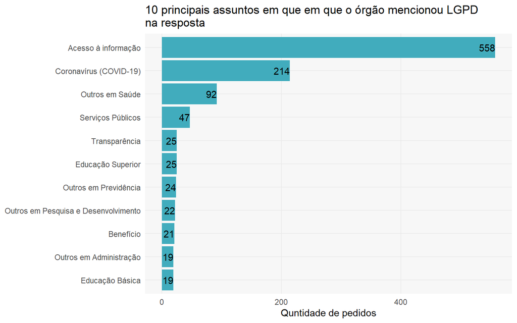

```r
lgpd %>%
  filter(
    usa_lgpd_resposta &
     !usa_lgpd_pedido &
     !usa_lgpd_pedido_resumido &
     assunto_pedido != "Dados Pessoais - LGPD"
  ) %>%
  count(assunto_pedido, sort = T) %>%
  slice_max(n = 10, order_by = n) %>%
  ggplot(aes(x = reorder(assunto_pedido, n), y = n)) +
  geom_col(fill = cores_tb[["azul"]]) +
  geom_text(aes(label = n), hjust = 1) +
  labs(
    title = "10 principais assuntos em que em que o órgão mencionou LGPD\nna resposta",
    y = "Quntidade de pedidos",
    x = NULL
  ) +
  coord_flip()
```

### Decisões quando órgão menciona LGPD

#### Geral

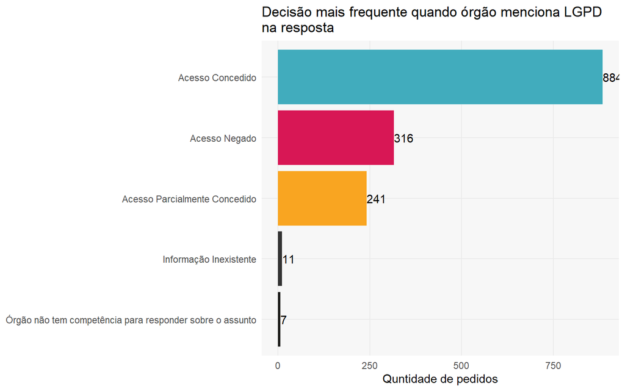

```r
lgpd %>%
  filter(
    usa_lgpd_resposta &
     !usa_lgpd_pedido &
     !usa_lgpd_pedido_resumido &
     assunto_pedido != "Dados Pessoais - LGPD"
  ) %>%
  count(decisao, sort = T) %>%
  ggplot(aes(x = reorder(decisao, n), y = n)) +
  geom_col(aes(fill = decisao), show.legend = F) +
  geom_text(aes(label = n), hjust = 0) +
  labs(
    title = "Decisão mais frequente quando órgão menciona LGPD\nna resposta",
    y = "Quntidade de pedidos",
    x = NULL
  ) +
  scale_fill_manual(values = cores_decisao2) +
  coord_flip()
```

#### Ano a ano

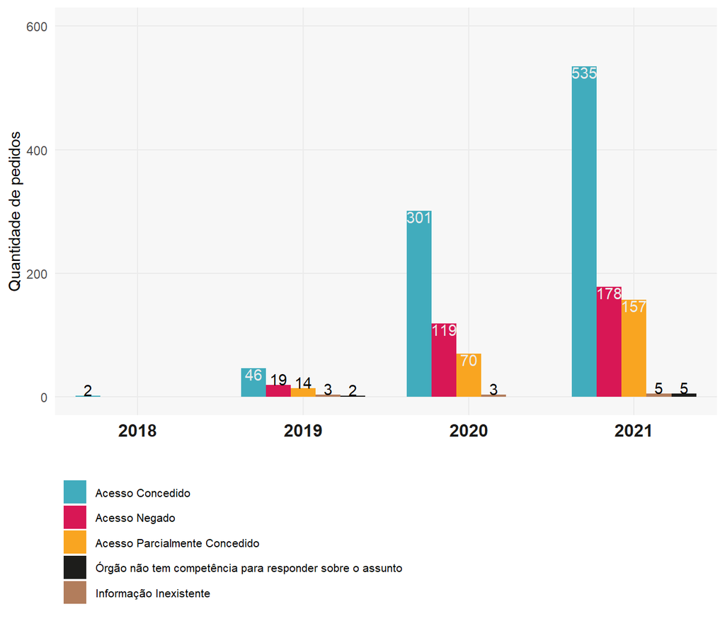

```r
cores_decisao_aux <- cores_decisao[-c(2, 5)]
cores_decisao_aux[["Informação Inexistente"]] <- cores_aep[["marrom"]]

lgpd %>%
  filter(
    usa_lgpd_resposta &
     !usa_lgpd_pedido &
     !usa_lgpd_pedido_resumido &
     assunto_pedido != "Dados Pessoais - LGPD"
  ) %>%
  count(ano = year(data_registro), decisao, sort = T) %>%
  complete(decisao, ano, fill = list(n = 0)) %>%
  #mutate(decisao = str_wrap(decisao, 25)) %>%
  #filter(ano > 2018) %>%
  ggplot(aes(x = reorder(ano, n), y = n, fill = decisao)) +
  geom_col(position = "dodge") +
  geom_text(
    aes(label = if_else(n > 20, n, NA_real_)),
    color = cores_tb[["cinza_quase_branco"]],
    position = position_dodge(width = .9),
    vjust = 1
  ) +
  geom_text(
    aes(label = if_else(n > 0 & n < 20, n, NA_real_)),
    position = position_dodge(width = .9),
    vjust = 0
  ) +
  scale_fill_manual(values = cores_decisao_aux) +
  ylim(c(0, 600)) +
  facet_wrap(ano ~ ., scales = "free_x", ncol = 5, strip.position = "bottom") +
  labs(
    title = NULL,
    y = "Quantidade de pedidos",
    x = NULL,
    fill = NULL
  ) +
  #guides(color = guide_legend(ncol = 1, title.position = "top")) +
  theme(
    axis.text.x = element_blank(),
    strip.text = element_text(hjust = 0.5, face = "bold", size = 12),
    legend.text = element_text(size = 8, margin = margin(5, 0, 5, 0, "pt")),
    legend.position = "bottom",
    legend.direction = "vertical",
    legend.justification = "left",
    panel.spacing = unit(0, "lines")
  )
```

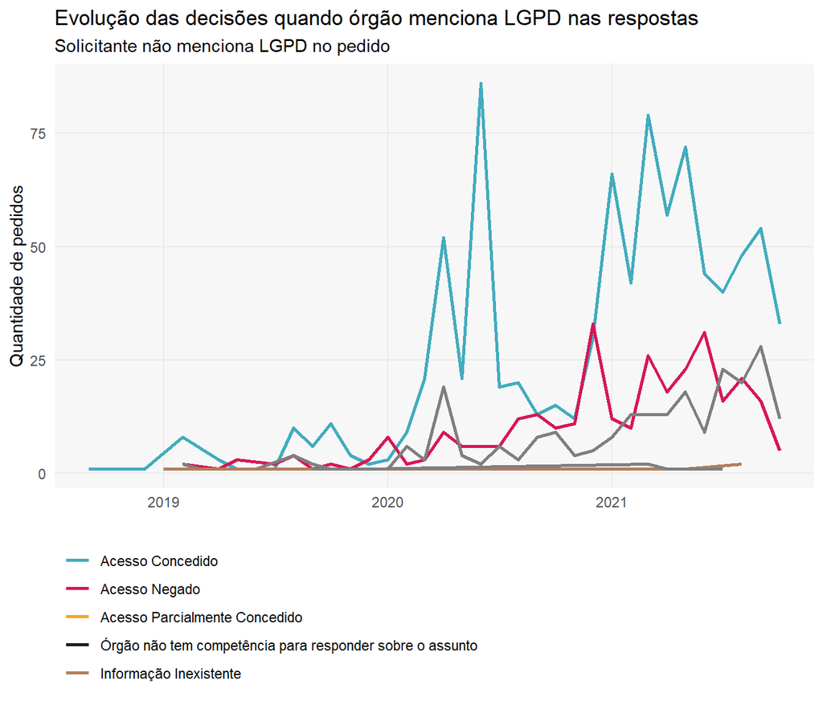

```r
lgpd %>%
  filter(
    usa_lgpd_resposta &
     !usa_lgpd_pedido &
     !usa_lgpd_pedido_resumido &
     assunto_pedido != "Dados Pessoais - LGPD"
  ) %>%
  count(data_registro, decisao, sort = T) %>%
  mutate(decisao = str_wrap(decisao, 25)) %>%
  ggplot(aes(x = data_registro, y = n, color = decisao)) +
  geom_line(size = 1) +
  scale_color_manual(values = cores_decisao_aux) +
  labs(
    title = "Evolução das decisões quando órgão menciona LGPD nas respostas",
    subtitle = "Solicitante não menciona LGPD no pedido",
    x = NULL,
    y = "Quantidade de pedidos",
    color = NULL
  ) +
  theme(
    legend.position = "bottom",
    legend.direction = "vertical",
    legend.justification = "left",
  )
```

### Lista de pedidos que usam a LGPD

```r
d <- lgpd %>%
  filter(usa_lgpd) %>%
  arrange(data_registro) %>%
  pull(id_pedido)

esic_url <- "http://www.consultaesic.cgu.gov.br/busca/_layouts/15/DetalhePedido/DetalhePedido.aspx?nup="

pedidos_cgu %>%
  filter(id_pedido %in% d) %>%
  left_join(lgpd) %>%
  transmute(
    `Onde a LGPD apareceu` = case_when(
      !usa_lgpd_assunto &
        !usa_lgpd_pedido &
        !usa_lgpd_pedido_resumido ~ str_glue(
          "Somente na resposta do órgão"
        ),
      TRUE ~ "Pedido ou assunto do pedido"
    ) %>% factor(),
    Protocolo = str_glue(
      '<a href="{esic_url}{protocolo_pedido}">{protocolo_pedido}</a>'
    ),
    Órgão = orgao,
   `Data registro` = dmy(ts_registro),
    Assunto = assunto_pedido,
    Decisão = decisao,
   `Resumo pedido` = resumo_solicitacao
  ) %>%
  DT::datatable(
    caption = str_glue(
      'Primeiras menções a LGPD',
      ' (clique no nº de protocolo para acessar o pedido no E-sic)'
    ),
    options = list(pageLength = 20, dom = 'tip'),
    filter = 'top',
    escape = FALSE
  )
```

|  | Onde a LGPD apareceu | Protocolo | Órgão | Data registro | Assunto | Decisão | Resumo pedido |
| --- | --- | --- | --- | --- | --- | --- | --- |
| 1 | Pedido ou assunto do pedido | 00077001198201892 | SGPR – Secretaria-Geral da Presidência da República | 2018-08-30 | Legislação | Acesso Concedido | pedidos de veto - Lei 13.709/18 |
| 2 | Pedido ou assunto do pedido | 00077001253201844 | SEGOV/PR - Secretaria de Governo da Presidência da República | 2018-09-10 | Legislação | Acesso Concedido | Solicito documentos relativos a sanção/veto do PLC 53/18 (Lei 13.709/18) |
| 3 | Pedido ou assunto do pedido | 03950003349201890 | ME - Ministério da Economia | 2018-09-11 | Serviços Públicos | Acesso Concedido | Solicito documentos relativos a sanção/veto do PLC 53/18 (Lei 13.709/18) |
| 4 | Pedido ou assunto do pedido | 01390001722201835 | MCTI – Ministério da Ciência, Tecnologia, Inovações | 2018-09-11 | Telecomunicações | Acesso Concedido | Solicito documentos relativos a sanção/veto do PLC 53/18 (Lei 13.709/18) |
| 5 | Pedido ou assunto do pedido | 52750000722201812 | ME - Ministério da Economia | 2018-09-11 | Outros em Comércio e serviços | Acesso Concedido | Solicito documentos relativos a sanção/veto do PLC 53/18 (Lei 13.709/18) |
| 6 | Pedido ou assunto do pedido | 25820005743201881 | MS – Ministério da Saúde | 2018-09-11 | Outros em Saúde | Acesso Parcialmente Concedido | Solicito documentos relativos a sanção/veto do PLC 53/18 (Lei 13.709/18) |
| 7 | Pedido ou assunto do pedido | 21900001314201893 | MAPA – Ministério da Agricultura, Pecuária e Abastecimento | 2018-09-11 | Produção Agropecuária | Acesso Concedido | Solicito documentos relativos a sanção/veto do PLC 53/18 (Lei 13.709/18) |
| 8 | Pedido ou assunto do pedido | 00075001324201829 | CGU – Controladoria-Geral da União | 2018-09-11 | Serviços Públicos | Acesso Parcialmente Concedido | Solicito documentos relativos a sanção/veto do PLC 53/18 (Lei 13.709/18) |
| 9 | Somente na resposta do órgão | 01390001725201879 | MCTI – Ministério da Ciência, Tecnologia, Inovações | 2018-09-11 | Telecomunicações | Acesso Concedido | Informações referentes à Mensagem de Veto nº 451, de 14 de agosto de 2018 |
| 10 | Pedido ou assunto do pedido | 00077001271201826 | CC-PR – Casa Civil da Presidência da República | 2018-09-14 | Legislação | Acesso Concedido | Exposição de motivos de lei |

[output cut: 3311 more lines]